# Final Report

due November 16, 2021 by 11:59 PM

Kaitlyn Lewars and Katie Meehl: The Exposure Experience

November 16, 2021

**Background and Significance**

Climate change has been a recurring topic in the news in recent years as it becomes a more pressing problem in the world. One of the important factors of climate change is air pollution. Air pollution refers to the release of pollutants into the air. To be more specific, pollutants are gases and chemicals that are released in the air usually due to energy use and production. Air pollutants like carbon dioxide and methane raise the earth’s temperature which contributes to climate change. Other air pollutants like smog and ozone are worsened by increased heat. Air pollution has varying effects on the human body depending on the type of air pollutant and length of exposure. However, we do know that overall air pollution is detrimental to human health and the planet as a whole. In 2017, air pollution was the 4th leading cause of mortality and the 5th leading cause of morbidity worldwide. Currently, WHO estimates that 9 out of 10 humans breathe air that exceeds the WHO’s guideline limits for pollutants, with those living in low- and middle-income countries suffering the most. As air pollution is a leading cause of morbidity and mortality, we thought it would be important to explore a data set investigating this problem.

In general, we would like to investigate air pollution as a cause of mortality globally to see 1) if the level of ambient air pollution concentration is correlated with number of deaths in a population or likelihood of an individual dying 2) what type of air pollution has the most effect on mortality. We hypothesize that ambient air pollution concentration and the likelihood of dying or number of deaths in a population are associated, with the higher the concentration of ambient air pollution the more likely an individual will die or more people from a population will die. We also hypothesize that ambient air pollution will have a greater effect on mortality because household air pollution is mainly a problem in low-income countries.

**Data Collection and Variables**

We downloaded this data from the World Health Organization Data Collections. There are several variables in this data including year, country, deaths by each type of air pollution, and deaths by other risk factors. We are focusing on the year 2016, which was the latest year data was collected in relation to air pollutants. Although the data includes how they died by diseases and illness influenced by air pollution, this will not be relevant in determining just correlation between types of air pollution and general morality. There are several different types of air pollution, but we will be looking at household and ambient matter pollution. We will compare these two variables to see which type of air pollution is the most fatal. We would also like to create a model to predict the amount of deaths per country or the likelihood of dying due to air concentration and other predictors. The main predictors we will look at are gender, amount of ambient air pollution (PM2.5), and the type of residence they live in.

The data collection is a bit complicated. In order to estimate deaths caused by pollution they use “mathematical functions, derived from epidemiological studies from countries around the world, that relate different levels of exposure to the increased risk of death or disability from each cause, by age and sex, where applicable, estimates of population exposure to PM2.5, ozone, and household air pollution, country-specific data on underlying rates of disease and death for each pollution-linked disease, and a comprehensive set of population data, adjusted to match the UN2015 Population Prospectus and obtained from the Gridded Population of the World (GPW) database for each country”.

**Exploratory Data Analysis**

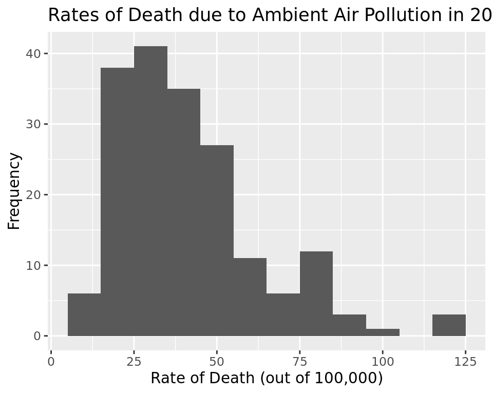

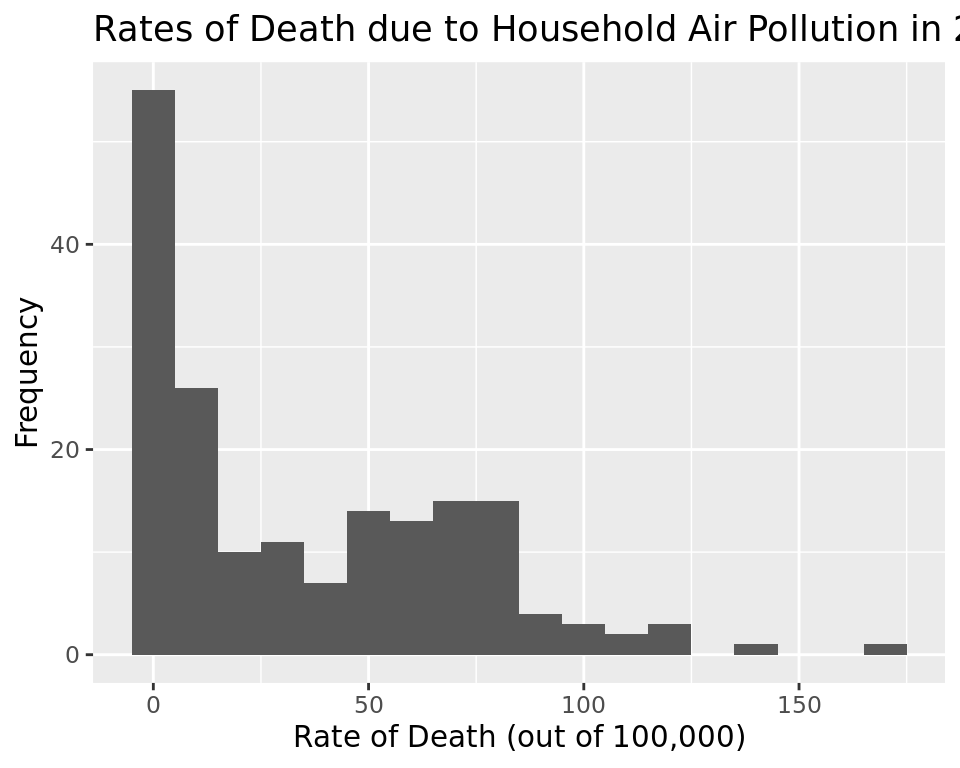

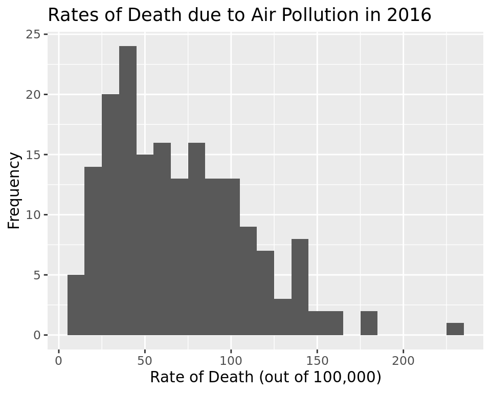

The first thing we wanted to look at was the frequency of higher death rates due to the ambient and household air pollution. As seen in the first visualization showing the rates of death due to Ambient Air Pollution, there tends to be a greater amount of countries that have death rates of around 25-30 out of every 100,000 in their population, with very few countries having less than 15 or greater than 75 deaths out of every 100,000.

This is much more alarming than the household air pollution death rates, which tend to center around 0 for most countries. However, this visualization also shows quite a few countries that have death rates between 50 and 100 deaths out of every 100,000.

Our third visualization shows the total deaths due to air pollution in selected countries around the globe in 2016. Here, we are able to see the sheer amount of countries that have had rates of roughly 50 up to roughly 150 deaths out of 100,000, indicating a serious global issue.

Out of these three plots, there are four countries that should be noted: Democratic People’s Republic of Korea, Georgia, Chad, and Bosnia and Herzegovina. These countries are outliers and show much higher death rates due to air pollution than other countries.

**Analytic Methods**

Before we did any analysis we had to wrangle the data. We created three different data sets. Two of them focused on the ambient air pollution. In the first data set, ambient, we filtered the data to only include location, sex, Cause of Death, Ambient air pollution death rate, total deaths from ambient air pollution, the concentration of ambient air pollution, and the total population. We then filtered this data to include “both sexes” from the sex variable and “total” from the cause of death variable. For the second data, ambient2, we used the same variables, but added residential type. This time we filtered out “both sexes” from the sex variable and “total” from residence type. Additionally we filtered this data to only include “total” from the cause of death variable. For the last data set, household, we did the same as our first data set where we selected the data to only include Location, Sex, Cause of Death, total deaths from ambient air pollution, total deaths from household air pollution, and the total population. These were the three data sets we used for this analysis.

At first we wanted to try to create a linear model to predict how many individuals will die due to ambient air pollution. To do this we first had to check if the data was normal and if the data was independent.

Within this graph, we normalized the total deaths due to ambient air pollution using the log function. We did this to create a normal distribution, so we could do a linear regression. Before doing this our deaths were skewed towards the left.

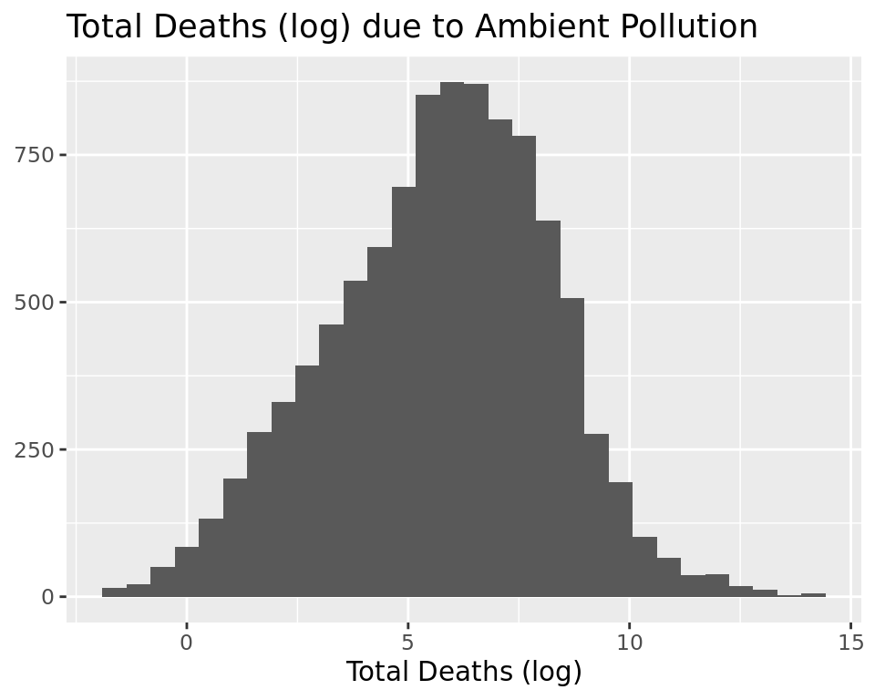

We want to explore the different factors affecting deaths due to ambient air pollution. A potential factor in the rise in environmental air pollution could be the concentration of air pollution. In the plot below, we examine the connection between total deaths from ambient air pollution vs. ambient air concentration in fine particulate matter, both of which are on a log scale for normalization of the data. Although slightly centered around the middle, the plot clearly shows a lack of strong relationship between these two variables, indicating that there are likely other factors influencing the data.

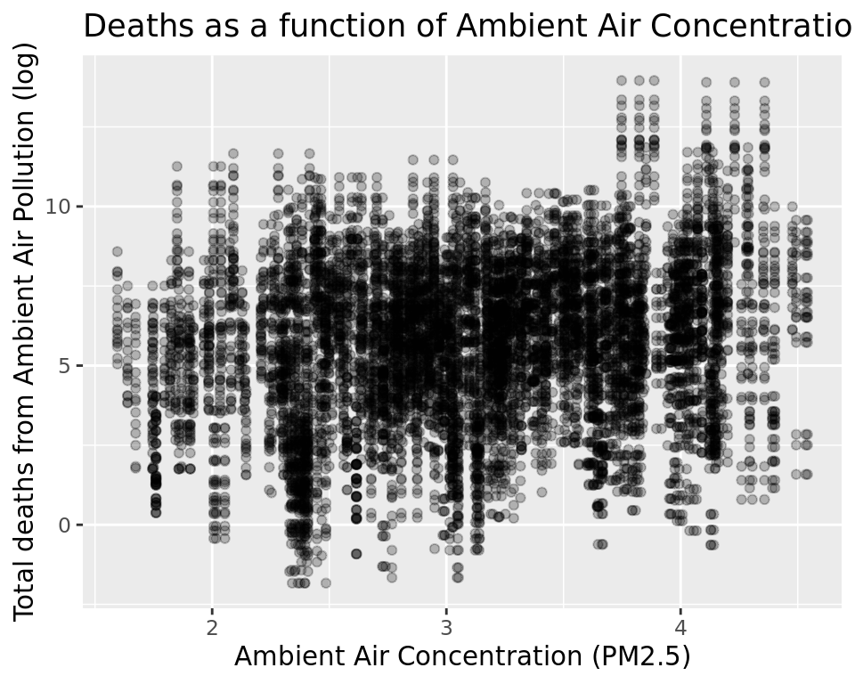

In continuing our exploration of which factors influence deaths and death rates from ambient air pollution, we compared the total deaths from ambient air pollution to the total population of the countries we selected to examine. Per the linear arrangement of points in the plot, there seems to be a strong relationship between the ambient air pollution deaths and the country population. This is likely because an increased population will naturally lead to a greater chance of citizens facing global health crisis. This also could be related to an increased amount and spread of ambient air pollution in larger countries which rely on greater usage of fossil fuels.

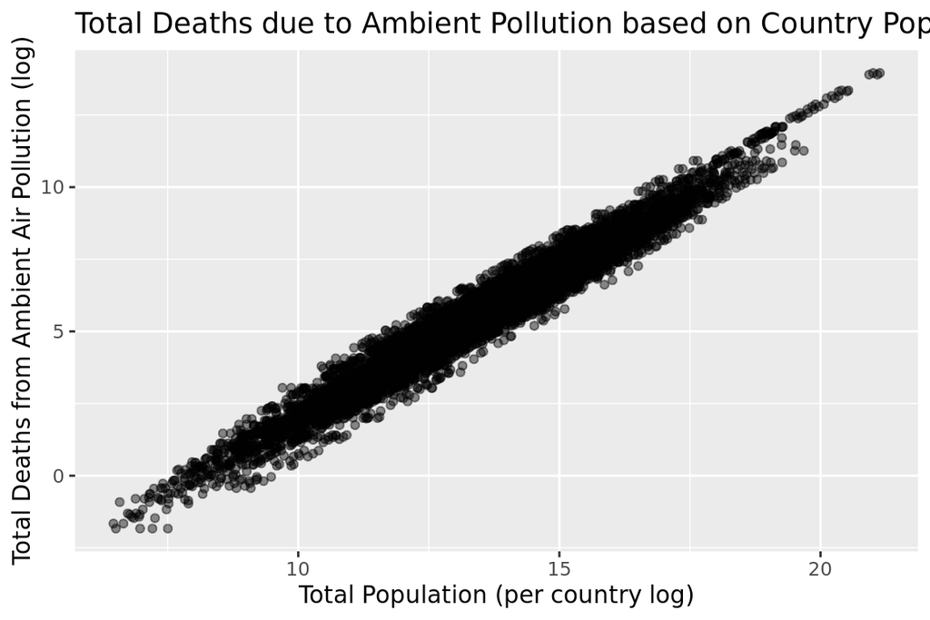

For the next 2 sections we created two different models for a linear regression to predict the total number of deaths in a certain population. The first one we did just based off the outdoor air concentration. While the p-value is 6.29e-87 which is less than 0.05 and the confidence interval of [0.673, 0.819] which does not contain 0 indicates that the air concentration variable is significant, the r squared value indicates that the model is not a good fit for the data as the R-squared value is 0.039, meaning the model only explains 3.9% variance in the model.

We then tried to improve the linear regression model by adding two predictors, residence type and gender. The residence types could either be urban or rural, while gender was either female or male.

Unfortunately, this linear regression model was also a bad fit for the data. The r-squared value was 0.038 so it only explains 3.8% of the data variance. Additionally the variables, gender and residence type, are not statistically significant as both of their p-values are greater then 0.05 and their confidence intervals contained 0.

|  | First Model |  |  | Model 2 |  |  |
| --- | --- | --- | --- | --- | --- | --- |
| Predictors | Estimates | Conf. Int (95%) | P-Value | Estimates | Conf. Int (95%) | P-Value |
| Intercept | 3.38 | 3.15 – 3.62 | **<0.001** | 3.45 | 3.24 – 3.66 | **<0.001** |
| Ambient Air Pollution Concentration (PM2.5) | 0.75 | 0.67 – 0.82 | **<0.001** | 0.74 | 0.67 – 0.80 | **<0.001** |
| Sex (Male) |  |  |  | -0.00 | -0.08 – 0.08 | 1.000 |
| Residence Type (Urban) |  |  |  | -0.07 | -0.15 – 0.02 | 0.117 |
| R<sup>2</sup> / R<sup>2</sup> adjusted | 0.039 / 0.039 |  |  | 0.038 / 0.038 |  |  |

Instead of continuing with linear regression models, we chose to create a binomial regression model to predict the likelihood of a person dying based on the level of ambient air concentration. We did this because the linear model was not predicting the data well as seen by r squared value of both linear models. For the binomial regression we made 4 assumptions: each observation falls into one of two categories called a success or failure, there is a fixed number of observations, the observations are all independent, and the probability of success (p) for each observation is the same - equally likely. By aggregating the data we created two categories of success and failure. There was a fixed number of observations, we assume that the data was collected in a random fashion. The only assumption that is hard to make is whether each individual has the same probability of dying or not, but we added predictors to account for these differences.

Here we created a binomial regression model to predict the likelihood of a person dying based on the level of ambient air concentration. The resulting equation likelihood of dying = 0.0003 + 1.0124(Ambient Air Concentration). Because the p-value is less than alpha = 0.05 and the confidence interval not containing 1 as an expected value indicates statistical significance and the odds ratio is within the confidence interval, we reject the null hypothesis and have enough evidence to say that ambient air concentration is related to dying. The odds ratio confirms that it is 1.0124 times more likely for individuals that experience ambient air concentration, specifically 1 PM2.5, to die than those who do not.

Here we created a binomial regression model to predict the likelihood of a person dying based on the level of ambient air concentration, gender, and where they live. The resulting equation is likelihood of dying = 0.0003 + 1.0124(Ambient Air Concentration) + 1.1822(Sex) + 0.9270(Residence Type). Because the p-values for all 3 of these variables are less than alpha = 0.05 and thus statistically significant, their confidence intervals don’t include 1 as expected values, and the odds ratio is within the confidence interval, we reject the null hypothesis and have enough evidence to say that ambient air concentration, sex and residential type are all related to dying from ambient air pollution. The odds ratio confirms that it is 1.1822 times more likely for males to die than females when the ambient air pollution concentration and the residence type is held constant. The odds ratio confirms that it is 0.9270 times more likely for someone living in a urban community to die than someone living in an rural community when the ambient air pollution concentration and gender are held constant.

|  | First Model |  |  | Model 2 |  |  |
| --- | --- | --- | --- | --- | --- | --- |
| Predictors | Odds Ratios | Conf. Int (95%) | P-Value | Odds Ratios | Conf. Int (95%) | P-Value |
| Intercept | 0.00 | 0.00 – 0.00 | **<0.001** | 0.00 | 0.00 – 0.00 | **<0.001** |
| Ambient Air Pollution Concentration (PM2.5) | 1.01 | 1.01 – 1.01 | **<0.001** | 1.01 | 1.01 – 1.01 | **<0.001** |
| Sex (Male) |  |  |  | 1.18 | 1.18 – 1.18 | **<0.001** |
| Residence Type (Urban) |  |  |  | 0.93 | 0.93 – 0.93 | **<0.001** |
| AIC | 9122755.592 |  |  | 8551995.502 |  |  |

While we cannot directly compare the models, we are concluding that the last model we made is the best one given the data we have. We are concluding this because the the two additional predictors we added are significant which likely means they are needed in addition to the air concentration graph. Also the AIC value in the second graph is smaller than the one in the first binomial regression, which indicates it is a better fit than the first model.

```
##
##  Paired t-test
##
## data:  household$Totaldeathshoushold and household$Totaldeathsambient
## t = -5.8255, df = 174959, p-value = 5.704e-09
## alternative hypothesis: true difference in means is not equal to 0
## 95 percent confidence interval:
##  -734.9047 -364.8837
## sample estimates:
## mean of the differences
##               -549.8942
```

```
##
##  Paired t-test
##
## data:  household$Totaldeathshoushold and household$Totaldeathsambient
## t = -5.8255, df = 174959, p-value = 2.852e-09
## alternative hypothesis: true difference in means is less than 0
## 95 percent confidence interval:
##       -Inf -394.6288
## sample estimates:
## mean of the differences
##               -549.8942
```

**Conclusions**

Through our analysis we have learned that ambient air pollution has an impact on mortality, furthermore we learned that ambient air pollution has a greater effect on mortality than household air pollution. This went along with our hypothesis made earlier. We also made a binomial regression model to predict the likelihood of a person dying due to ambient air pollution. This was a bit different than the original plan as we originally sought to create a model that would predict for the whole population. Through this regression model we found that it is more likely that an individual in an rural community to die due to air pollution than someone living in a urban community. We also found that a male is more likely to die than female.

We did have a limitation with the t-tests, which was that household and ambient air pollution are likely highly correlated. We haven’t learned how to test and adjust for this so this could be affecting the results. Another limitation we encountered was that we didn’t have the data for multiple years which we think would have been a great addition and would have allowed us to interpret trends in the effects of air pollution globally. We created a binomial model for this data set, however since air pollution does not effect just one country or a small group of people a way to predict the deaths per country according to population size.

In terms of next steps, we need to find a way to do a correlation test and perhaps gather data from multiple years. We should also gather some training data to test how well our model is predicting individuals. Finally, in the future, we can also begin examining specifically how ambient or household air pollution affects certain populations medically, example being what type of illness due to air pollution will be most prevalent population by gender or residence. This was not our original intention, but would now be possible knowing significant factors which affect air pollution death.

- World Health Organization. “Air Pollution.” World Health Organization, World Health Organization, 22 Sept. 2021, https://www.who.int/health-topics/air-pollution#tab=tab_1.
- State of Global Air. “State of Global Air.” How We Estimate Burden of Disease | State of Global Air, 2021, https://www.stateofglobalair.org/data/estimate-burden.